# Analiza skupień

Adam Michalski

# Zadanie 1

Na początek wczytujemy dane oraz przygotowujemy kolumny do grupowania:

```r
library(datasets)
data(iris)
data_clusters <- subset(iris, select = -c(Species))
summary(data_clusters)
```

```
##   Sepal.Length    Sepal.Width     Petal.Length    Petal.Width
##  Min.   :4.300   Min.   :2.000   Min.   :1.000   Min.   :0.100
##  1st Qu.:5.100   1st Qu.:2.800   1st Qu.:1.600   1st Qu.:0.300
##  Median :5.800   Median :3.000   Median :4.350   Median :1.300
##  Mean   :5.843   Mean   :3.057   Mean   :3.758   Mean   :1.199
##  3rd Qu.:6.400   3rd Qu.:3.300   3rd Qu.:5.100   3rd Qu.:1.800
##  Max.   :7.900   Max.   :4.400   Max.   :6.900   Max.   :2.500
```

Wyniki grupowania metodą 3 średnich wyświetlamy poprzez funkcję plot:

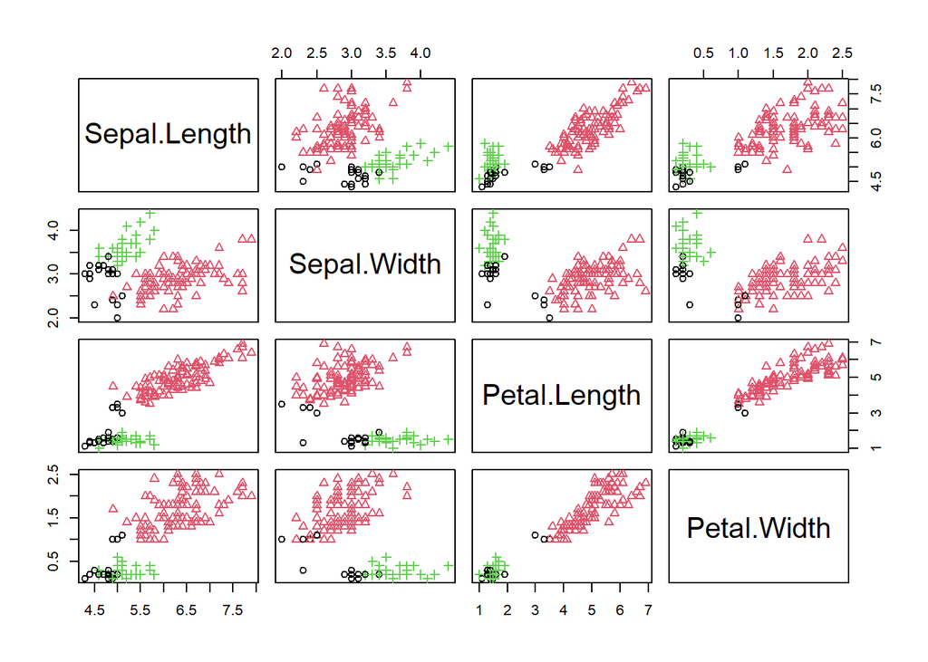

```r
set.seed(14)
iris3means <- kmeans(data_clusters, 3)
iris$cluster3means <- iris3means$cluster

plot(data_clusters, pch = iris$cluster3means, col = iris$cluster3means)
points(iris3means$centers, cex=2, pch=19)
```

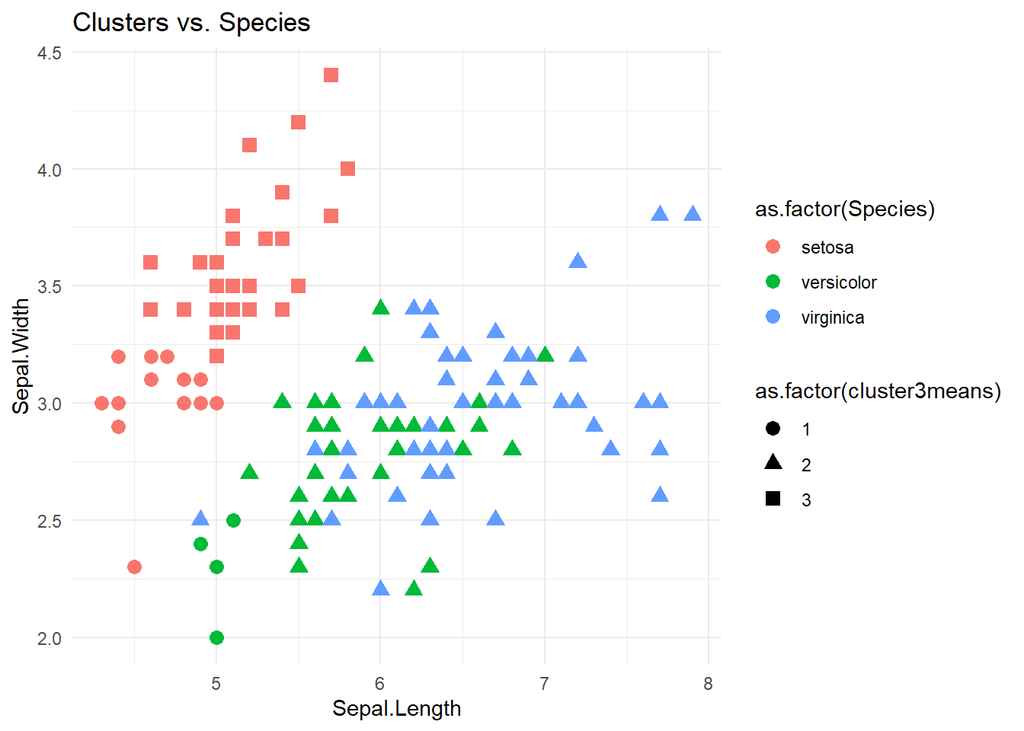

```r
library(ggplot2)
ggplot(iris, aes(x = Sepal.Length, y = Sepal.Width, color = as.factor(Species), shape = as.factor(cluster3means))) +
  geom_point(size = 3) +
  ggtitle("Clusters vs. Species") +
  theme_minimal()
```

Dodatkowo możemy porównać w postaci macierzy pomyłek otrzymane klastry z gatunkami (jest to wtedy numeryczna weryfikacja metody klastrowania z nadzorem):

```r
library(caret)
confusion_matrix <- table(Clusters = iris$cluster3means, Species = iris$Species)
print(confusion_matrix)
```

```
##         Species
## Clusters setosa versicolor virginica
##        1     17          4         0
##        2      0         46        50
##        3     33          0         0
```

Okazuje się, że otrzymane klastry nie pokrywają się z gatunkami irysów. Drugi klaster zdaje się zawierać wszystkie irysy gatunku virginica oraz większość gatunku versicolor, podczas gdy pozostałe klastry dzielą dogłębniej gatunek setosa. Podobne porównanie przeprowadzamy dla algorytmu EM:

```r
library(mclust)
```

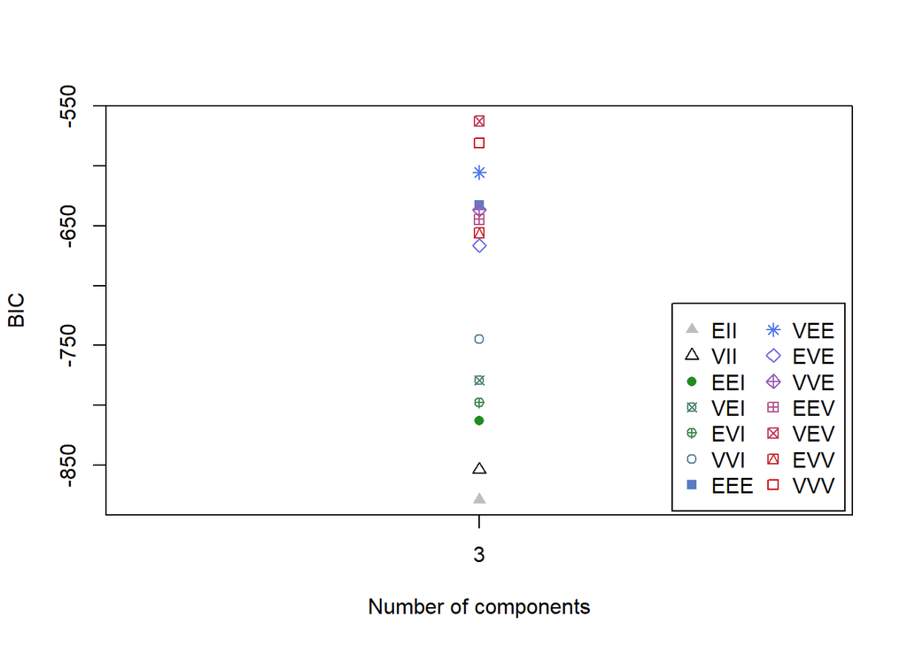

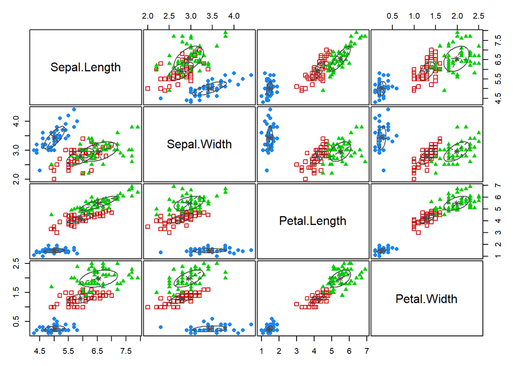

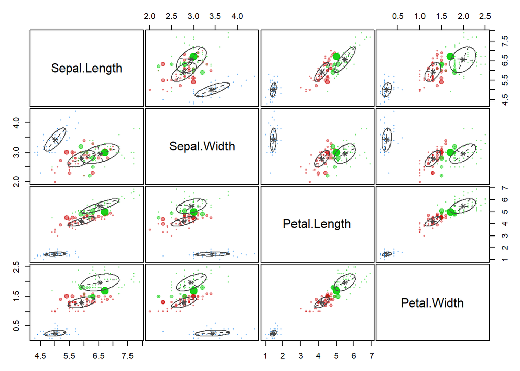

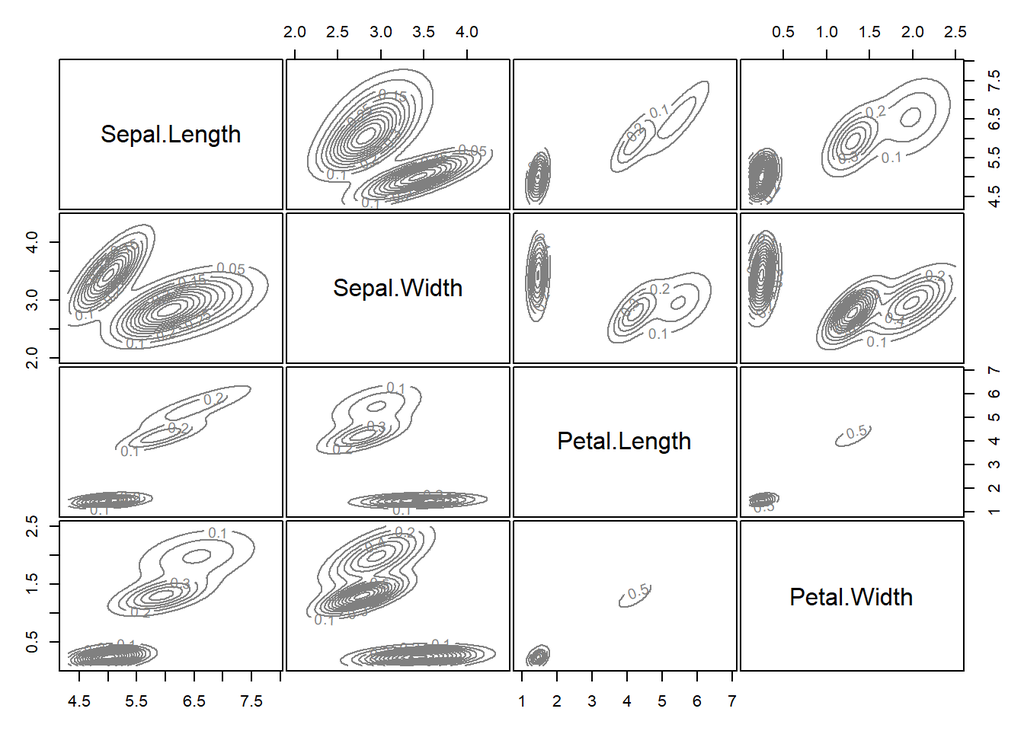

```r
set.seed(14)
iris3EM <- Mclust(data_clusters, G = 3)
iris$cluster3EM <- iris3EM$classification
plot(iris3EM)
```

Z pierwszego wykresu możemy odczytać wybrany na podstawie kryterium informacyjnego model. Z wykresów klastry zdają się łudząco przypominać gatunki irysów. Macierz pomyłek wygląda następująco:

```r
library(caret)
confusion_matrix <- table(Clusters = iris$cluster3EM, Species = iris$Species)
print(confusion_matrix)
```

```
##         Species
## Clusters setosa versicolor virginica
##        1     50          0         0
##        2      0         45         0
##        3      0          5        50
```

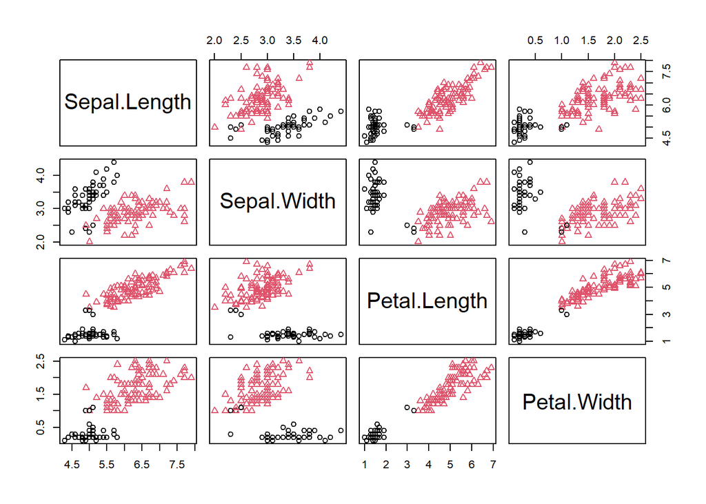

```r
set.seed(14)
iris2means <- kmeans(data_clusters, 2)
iris$cluster2means <- iris2means$cluster

plot(data_clusters, pch = iris$cluster2means, col = iris$cluster2means)
points(iris2means$centers, cex=2, pch=19)
```

Macierz pomyłek względem gatunków:

```r
library(caret)
confusion_matrix <- table(Clusters = iris$cluster2means, Species = iris$Species)
print(confusion_matrix)
```

```
##         Species
## Clusters setosa versicolor virginica
##        1     50          3         0
##        2      0         47        50
```

Na podstawie macierzy pomyłek i wykresów algorytm 2 średnich zdaje się prowadzić do grupowania łączącego gatunki virginica i versicolor.Następnie przyjrzymy się klastrom powstałym przy użyciu algorytmu 4 średnich:

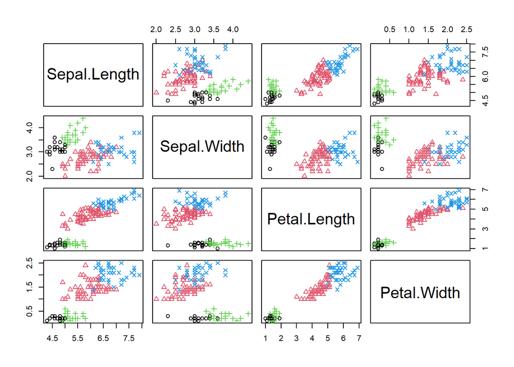

```r
set.seed(14)
iris4means <- kmeans(data_clusters, 4)
iris$cluster4means <- iris4means$cluster

plot(data_clusters, pch = iris$cluster4means, col = iris$cluster4means)
points(iris2means$centers, cex=2, pch=19)
```

Macierz pomyłek względem gatunków:

```r
library(caret)
confusion_matrix <- table(Clusters = iris$cluster4means, Species = iris$Species)
print(confusion_matrix)
```

```
##         Species
## Clusters setosa versicolor virginica
##        1     22          0         0
##        2      0         48        14
##        3     28          0         0
##        4      0          2        36
```

Grupowanie to zdaje się rozbijać gatunek setosa na klastry 1 i 3 oraz pozostałe klastry stanowią pewien podział pozostałych gatunków. Zróbmy to samo gla algorytmu EM najpierw dla 2 klastrów:

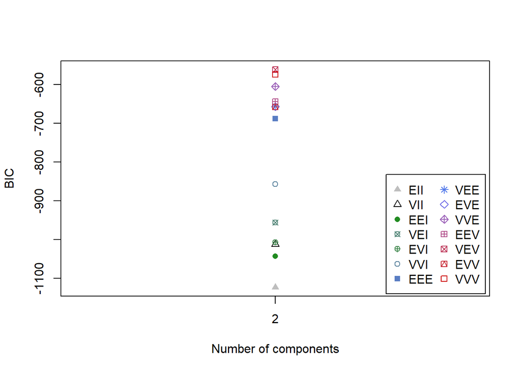

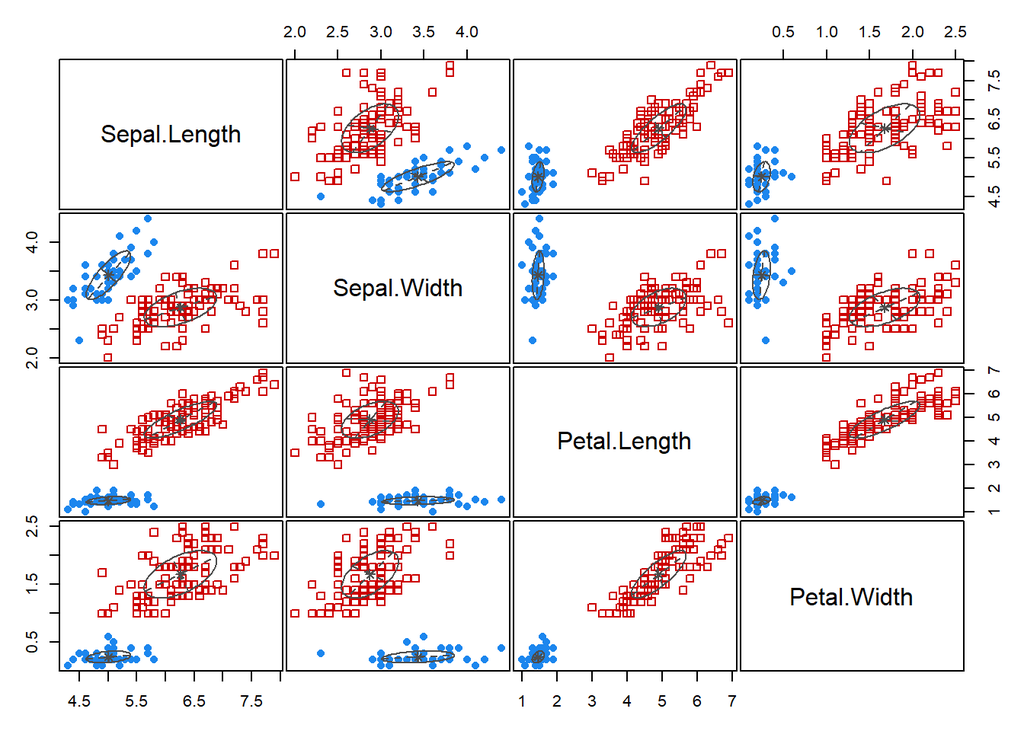

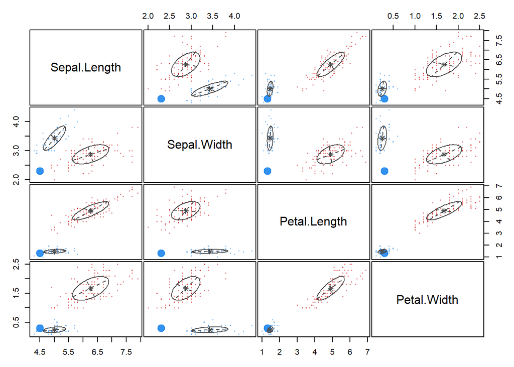

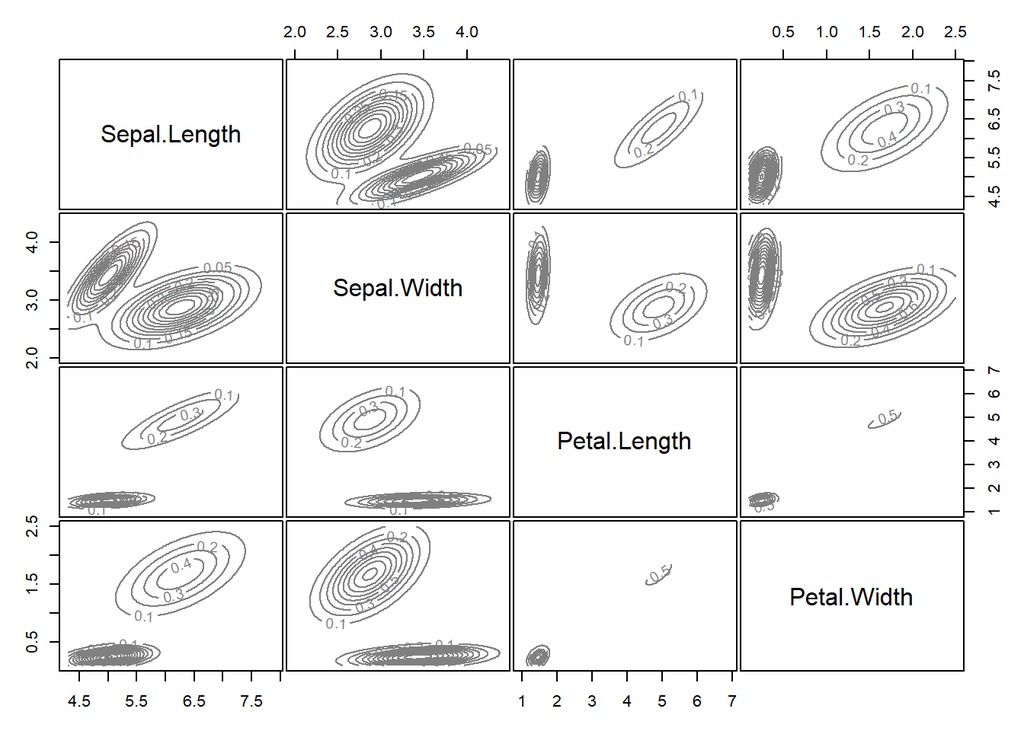

```r
library(mclust)
set.seed(14)
iris2EM <- Mclust(data_clusters, G = 2)
iris$cluster2EM <- iris2EM$classification
plot(iris2EM)
```

Macierz pomyłek:

```r
library(caret)
confusion_matrix <- table(Clusters = iris$cluster2EM, Species = iris$Species)
print(confusion_matrix)
```

```
##         Species
## Clusters setosa versicolor virginica
##        1     50          0         0
##        2      0         50        50
```

Otrzymane klastry przy pomocy algorytmu EM pokrywają się dokładnie z połączeniem gatunków virginica i versicolor pozostawiając gatunek setosa w osobnym klastrze. Teraz EM z podziałem na 4 klastry:

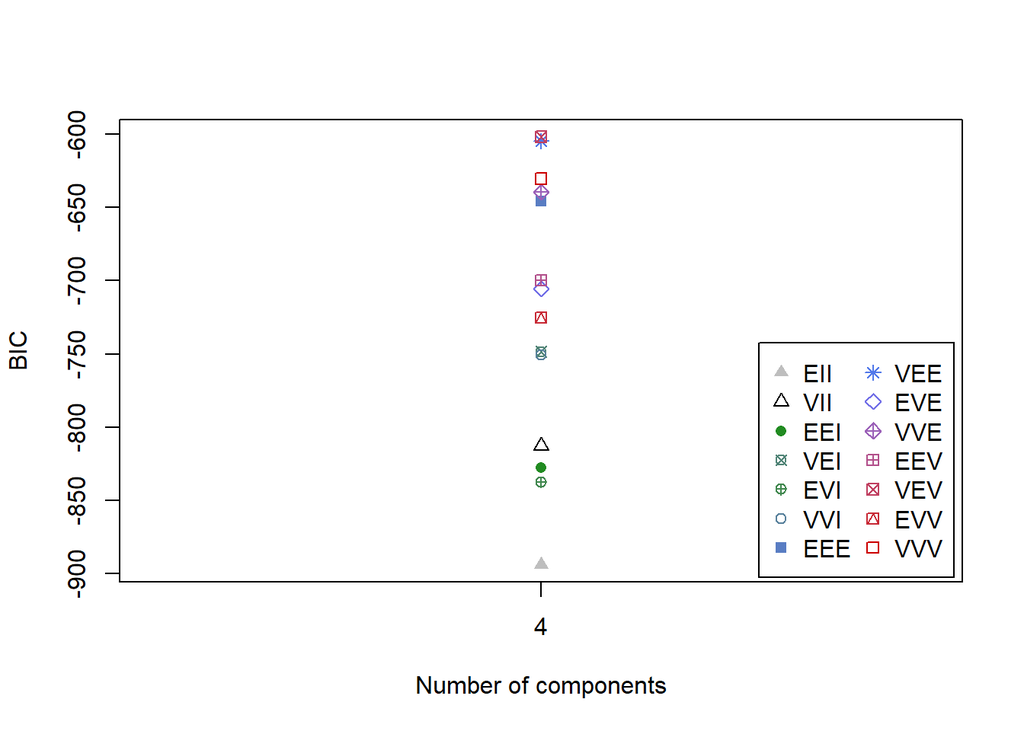

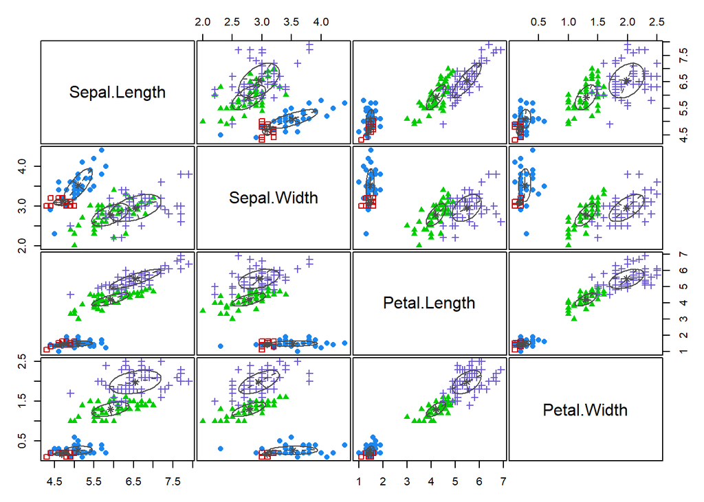

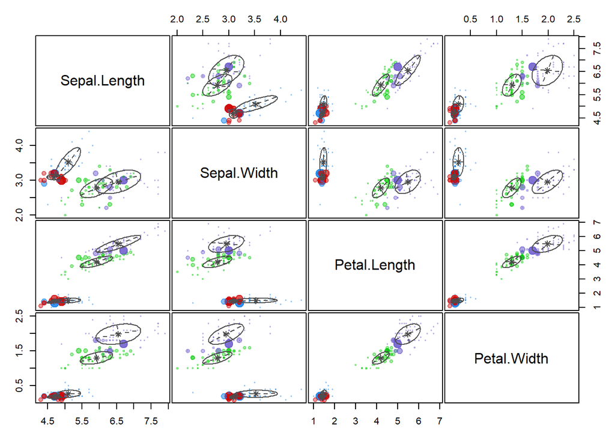

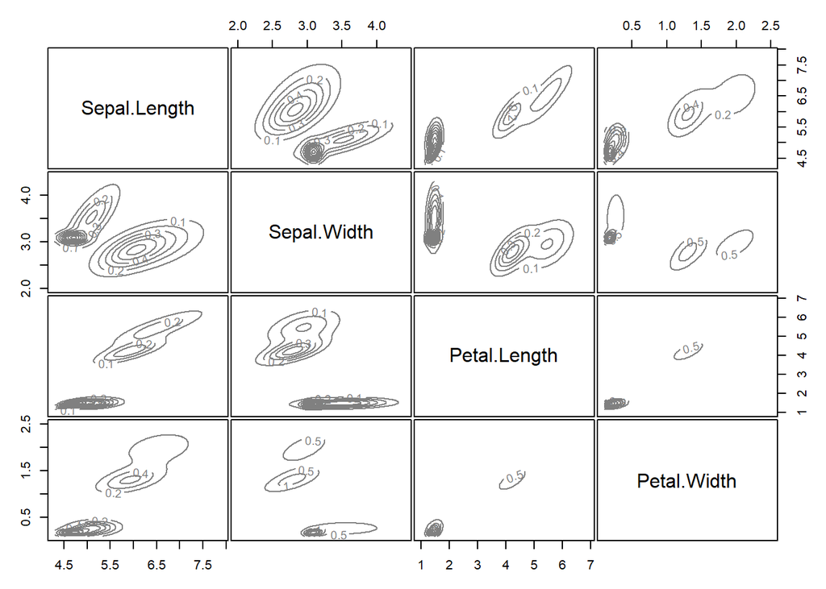

```r
library(mclust)
set.seed(14)
iris4EM <- Mclust(data_clusters, G = 4)
iris$cluster4EM <- iris4EM$classification
plot(iris4EM)
```

```r
library(caret)
confusion_matrix <- table(Clusters = iris$cluster4EM, Species = iris$Species)
print(confusion_matrix)
```

```
##         Species
## Clusters setosa versicolor virginica
##        1     38          0         0
##        2     12          0         0
##        3      0         45         0
##        4      0          5        50
```

Otrzymane klastry przy pomocy algorytmu EM podobnie jak te algorytmu 4 średnich dzielą gatunek setosa na 2 klastry. Algorytm EM zdaje się jednak być blisko podziału gatunków versicolor i virginica na osobne klastry.

# Zadanie 3

Najpierw wczytujemy początkowe dane bez braków:

```r
library(PogromcyDanych)
data(auta2012)
summary(auta2012)
```

```
##       Cena              Waluta         Cena.w.PLN       Brutto.netto
##  Min.   :     174   PLN    :181844   Min.   :     400   brutto:191989
##  1st Qu.:   10900   CZK    : 19070   1st Qu.:   10900   netto : 15613
##  Median :   21500   EUR    :  5407   Median :   19900
##  Mean   :   54929   USD    :   658   Mean   :   35755
##  3rd Qu.:   44900   HUF    :   611   3rd Qu.:   37471
##  Max.   :22230000   CHF    :     5   Max.   :11111111
##                     (Other):     7
##        KM                kW                     Marka            Model
##  Min.   :    1.0   Min.   :    1.00   Volkswagen   : 22826   Passat :  6883
##  1st Qu.:   90.0   1st Qu.:   66.00   Opel         : 19092   Astra  :  6348
##  Median :  115.0   Median :   85.00   Ford         : 17717   Golf   :  6096
##  Mean   :  127.4   Mean   :   93.69   Renault      : 17498   Focus  :  5691
##  3rd Qu.:  140.0   3rd Qu.:  103.00   Audi         : 12851   A4     :  4280
##  Max.   :21754.0   Max.   :16000.00   Mercedes-Benz: 10945   Mondeo :  4252
##  NA's   :27069     NA's   :27069      (Other)      :106673   (Other):174052
##      Wersja      Liczba.drzwi Pojemnosc.skokowa Przebieg.w.km
##         :97447      :  5716   Min.   :    10    Min.   :        1
##  II     :19946   2/3: 31674   1st Qu.:  1586    1st Qu.:    85000
##  I      :12391   4/5:170212   Median :  1896    Median :   140000
##  III    : 9225                Mean   :  1944    Mean   :   147167
##  IV     : 4295                3rd Qu.:  2000    3rd Qu.:   180000
##  B      : 3775                Max.   :151000    Max.   :999999999
##  (Other):60523                NA's   :6165      NA's   :39559
##                 Rodzaj.paliwa    Rok.produkcji                 Kolor
##  benzyna               : 81694   Min.   :1900   srebrny-metallic  :40626
##  benzyna+LPG           : 10684   1st Qu.:2000   czarny-metallic   :29129
##  etanol                :    28   Median :2004                     :25997
##  hybryda               :   183   Mean   :2003   niebieski-metallic:12584
##  naped elektryczny     :    55   3rd Qu.:2007   szary-metallic    :10834
##  olej napedowy (diesel):114958   Max.   :2012   granatowy-metallic:10756
##                                                 (Other)           :77676
##  Kraj.aktualnej.rejestracji Kraj.pochodzenia Pojazd.uszkodzony
##          :103809                   :89064       :195099
##  Polska  : 91010            Niemcy :49877    Tak: 12503
##  Niemcy  :  6744            Polska :31324
##  Francja :  2052            Francja: 8909
##  Belgia  :   849            Czechy : 6161
##  Holandia:   813            Belgia : 5713
##  (Other) :  2325            (Other):16554
##      Skrzynia.biegow                           Status.pojazdu.sprowadzonego
##              :  6697                                         :131275
##  automatyczna: 33888   do sprowadzenia                       :  2703
##  manualna    :167017   przygotowany do rejestracji / oplacony: 28596
##                        sprowadzony / nieoplacony             : 12295
##                        sprowadzony / zarejestrowany          : 32733
##
##
##                                                                                                                                                       Wyposazenie.dodatkowe
##                                                                                                                                                                  :  7982
##  ABS, el. szyby, el. lusterka, klimatyzacja, centralny zamek, poduszka powietrzna, radio / CD, wspomaganie kierownicy, immobiliser                               :  1090
##  ABS, el. szyby, el. lusterka, klimatyzacja, centralny zamek, poduszka powietrzna, radio / CD, wspomaganie kierownicy, immobiliser, komputer                     :  1018
##  ABS, el. szyby, klimatyzacja, centralny zamek, poduszka powietrzna, radio / CD, wspomaganie kierownicy, immobiliser                                             :   718
##  ABS, el. szyby, el. lusterka, klimatyzacja, centralny zamek, poduszka powietrzna, radio / CD, wspomaganie kierownicy, immobiliser, welurowa tapicerka           :   645
##  ABS, el. szyby, el. lusterka, klimatyzacja, centralny zamek, autoalarm, poduszka powietrzna, radio / CD, wspomaganie kierownicy, immobiliser, welurowa tapicerka:   571
##  (Other)                                                                                                                                                         :195578
```

```r
chosen_data <- na.omit(auta2012[1:10000, ])
length(chosen_data$Cena)
```

```
## [1] 6979
```

```r
unpure_data <- subset(chosen_data, select = c(KM , Pojemnosc.skokowa, Marka))
```

Otrzymaliśmy 6979 wierszy. W następnej kolejności usuniemy dane odstające:

```r
km_quantile <- quantile(unpure_data$KM, 0.98)
pojemnosc_quantile <- quantile(unpure_data$Pojemnosc.skokowa, 0.98)

pure_data <- unpure_data[unpure_data$KM <= km_quantile &
                              unpure_data$Pojemnosc.skokowa <= pojemnosc_quantile, ]
length(pure_data$KM)
```

```
## [1] 6786
```

```r
summary(pure_data)
```

```
##        KM        Pojemnosc.skokowa           Marka
##  Min.   :  5.0   Min.   :  14      Ford         : 687
##  1st Qu.: 90.0   1st Qu.:1595      Opel         : 672
##  Median :115.0   Median :1900      Volkswagen   : 646
##  Mean   :129.5   Mean   :1972      Renault      : 516
##  3rd Qu.:150.0   3rd Qu.:2000      Audi         : 475
##  Max.   :387.0   Max.   :4966      Mercedes-Benz: 396
##                                    (Other)      :3394
```

```r
data_for_clusters <- subset(pure_data, select = -c(Marka))
```

Pozostało 6786 wierszy. Przejdźmy do użycia algorytmu EM do stworzenia klastrów:

```r
num_clusters <- 5
library(mclust)
set.seed(14)
carsEM <- Mclust(data_for_clusters, G=num_clusters)
pure_data$clusterEM <- carsEM$classification
```

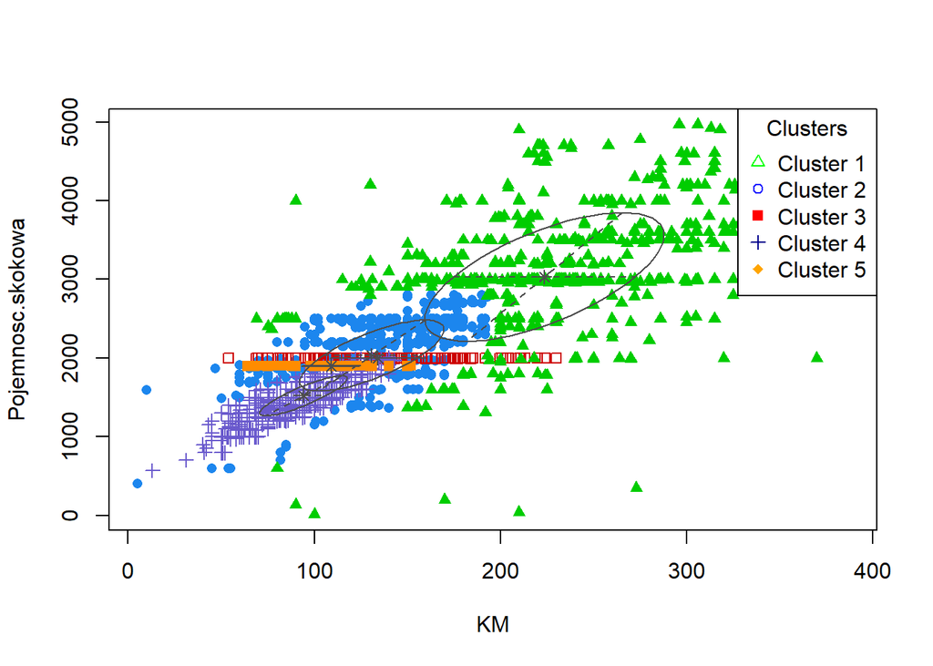

```r
cluster_colors <- c("green", "blue", "red", "darkblue", "orange")
cluster_symbols <- c(2, 1, 15, 3, 18)  # Triangle, circle, square, plus, rhombus

plot(carsEM, what = "classification")

legend_labels <- paste("Cluster", sort(unique(pure_data$clusterEM)))
legend("topright", legend = legend_labels, pch = cluster_symbols, col = cluster_colors, title = "Clusters")
```

```r
pure_data$Marka <- as.character(pure_data$Marka)
most_common_vals <- names(sort(table(pure_data$Marka), decreasing = TRUE))[1:10]
pure_data$clean_Marka <- ifelse(pure_data$Marka %in% most_common_vals, pure_data$Marka, "Other")
library(caret)
confusion_matrix <- table(Cluster = pure_data$clusterEM, Marka = pure_data$clean_Marka)
print(confusion_matrix)
```

```
##        Marka
## Cluster Audi BMW Fiat Ford Mercedes-Benz Opel Other Peugeot Renault Toyota
##       1   86  28   31   33           161  127   370      23      55     57
##       2   64 126    8  161            24   86   348      87      65     96
##       3  126 163    4   26           169   19   382       8      12     31
##       4   98  24  168  446            41  392   926     221     328    106
##       5  101   7   18   21             1   48   161       1      56      0
##        Marka
## Cluster Volkswagen
##       1         83
##       2         49
##       3         36
##       4        220
##       5        258
```

Z macierzy powyższej widać, że chociażby samochody o rzadszych markach występują najczęściej w grupie 4 oraz w grupie 5 nie pojawiają się Toyoty oraz występują pojedyńcze Peugeoty i Mercedesy. Ze względu na niewielką liczność występowania nawet najczęstszych marek szczegółowe zależności marki od klastra są trduniej dostępne.